# Anthropogenic_Climate

Zjrobbin

5/20/2020

## Overview:

This script calculates a minimum and maximum temperature vector for the IMAP/TDIA model that reflects the difference in monthly means between the two time periods analyzed. To do this we will first compare the PRISM monthly historic means, with the monthly means from the observed temperatures used to run the model for each of the four sites. Then we will use the monthly difference to calculate a new daily driver that removes this difference, thus creating the historic. Zachary Robbins 01/05/21

> Historical data from

> http://www.prism.oregonstate.edu/historical/

> From their description “Time series datasets prior to 1981 are modeled using climatologically-aided interpolation (CAI), which uses the long-term average pattern (i.e., the 30-year normals) as first-guess of the spatial pattern of climatic conditions for a given month or day. CAI is robust to wide variations in station data density, which is necessary when modeling long time series. Data is based on monthly modeling. These datasets use whatever station networks and data sources are available for the relevant period.”

## Maximum Temperature

### Then we load in our DayMet data from 2003-2018

Here is the comparison between the monthly mean between the study domain (2003-2018), and the historic nomral (1895-1945).

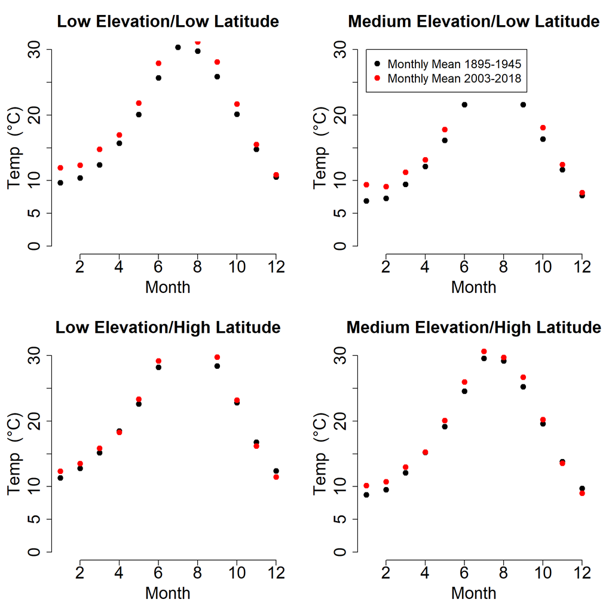

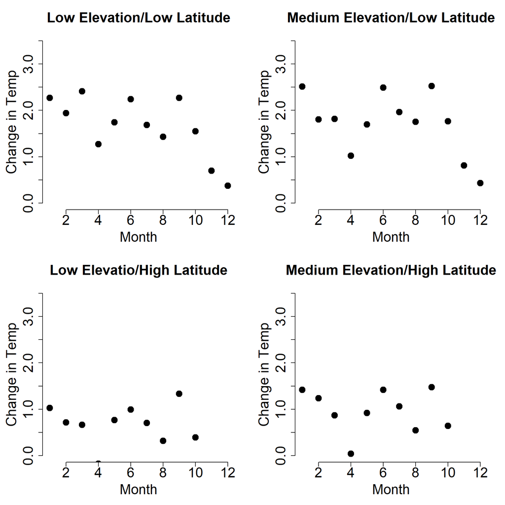

## Minimum Temperature

```
##      X      Dates Low_LowElShape_Out Low_MedElShape_Out Low_HighElShape_Out
## 1 6479 2001-10-01          14.661702          12.071701            9.738400
## 2 6480 2001-10-02          14.169415          11.678490            9.470667
## 3 6481 2001-10-03          13.797473          11.031655            8.621867
## 4 6482 2001-10-04          12.881117          10.020086            7.530667
## 5 6483 2001-10-05           9.394548           7.021231            5.274933
## 6 6484 2001-10-06           7.242553           4.505085            2.327733
##   High_LowElShape_Out High_MedElShape_Out High_HighElShape_Out
## 1           17.312402           15.084586            11.821497
## 2           17.270052           14.750627            11.624952
## 3           16.358683           13.951963            10.951823
## 4           13.601663           12.173141             9.777927
## 5            9.318692            8.387009             6.981766
## 6            7.787463            6.947368             5.462188
```

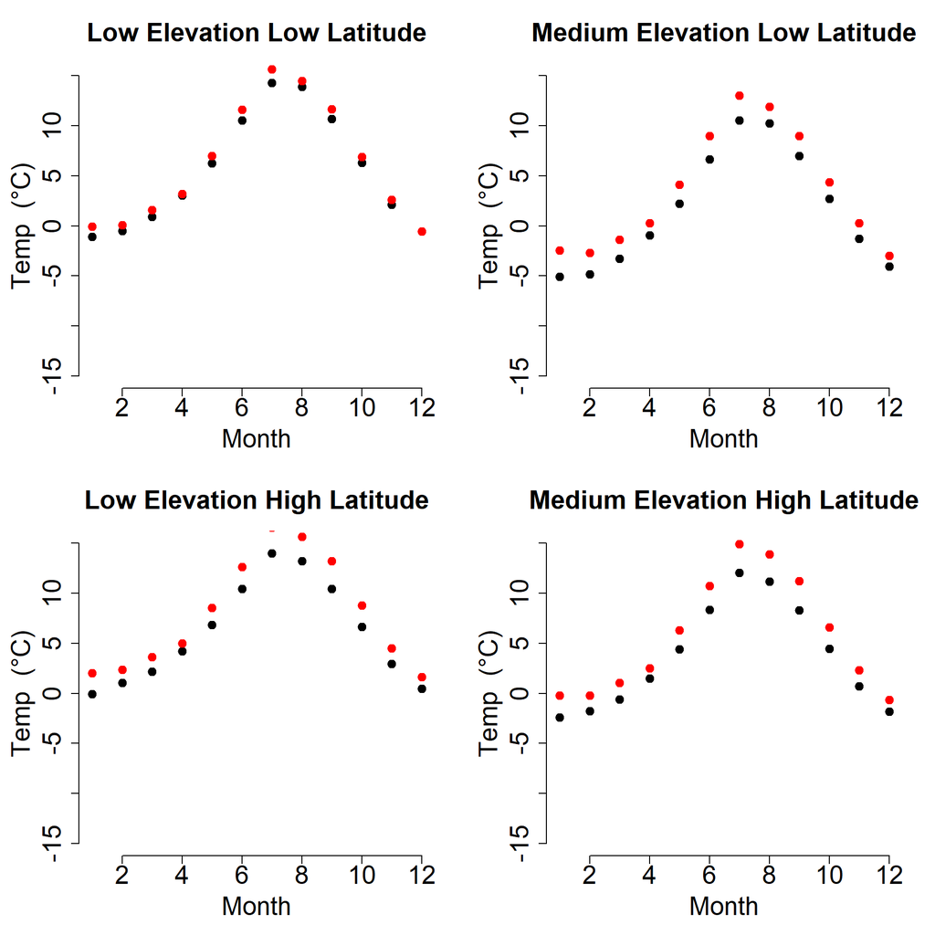

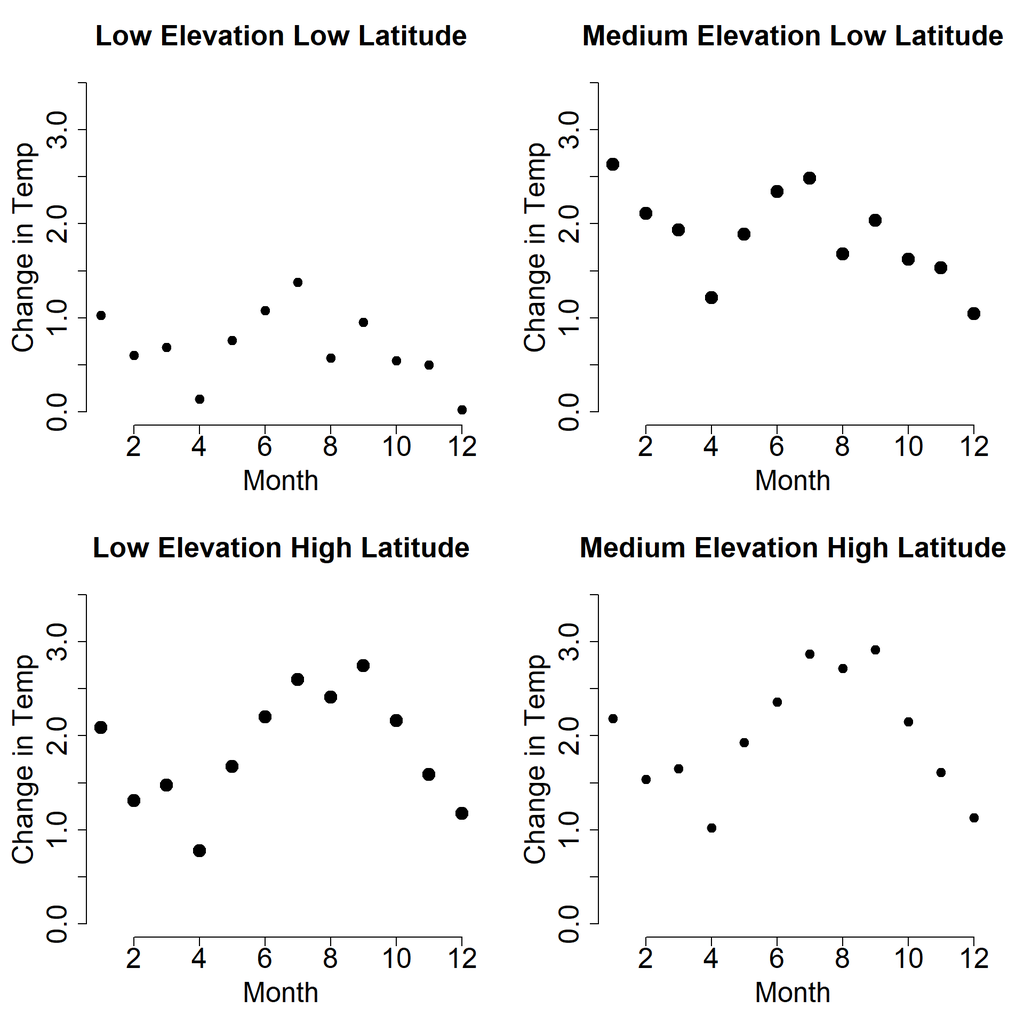

### T-Means

The means are not used in the model, but are descriptive and used to show the difference between the two climate drivers.

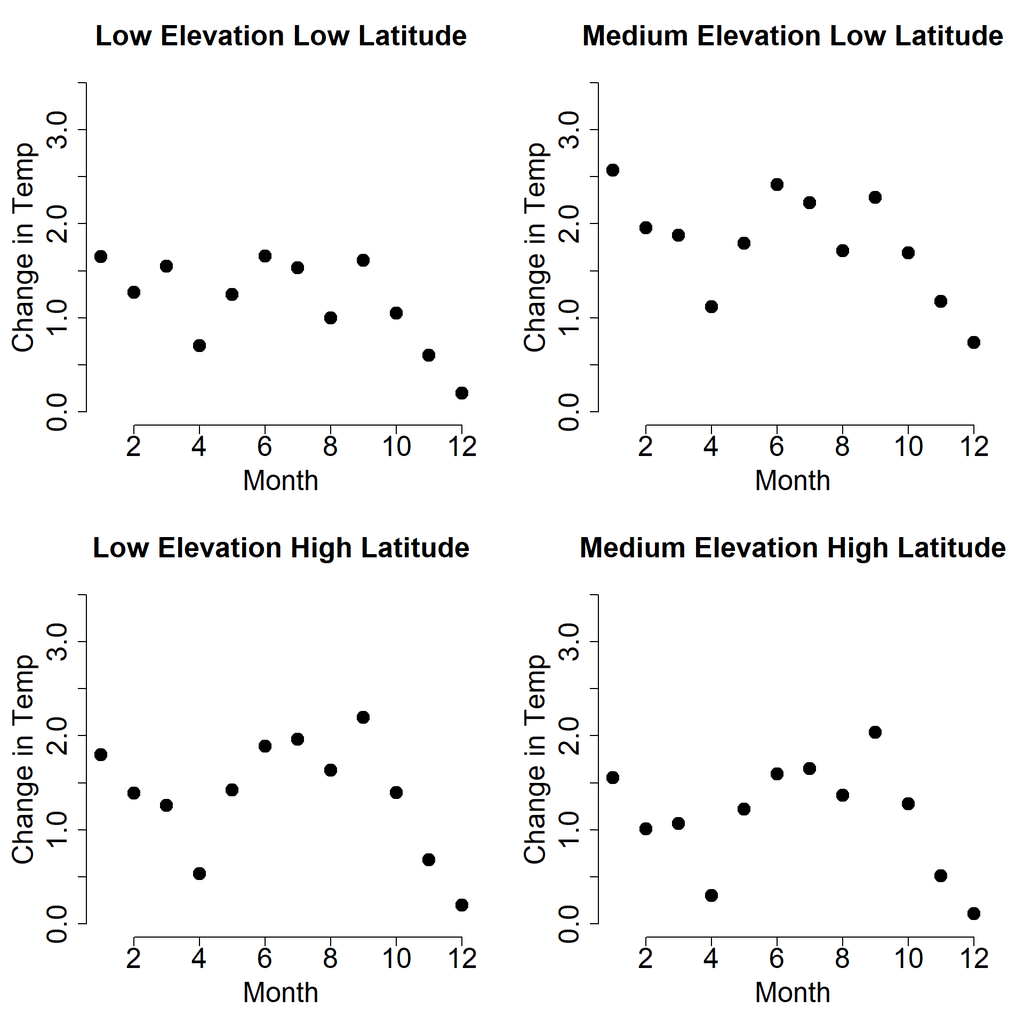

[figure not shown]

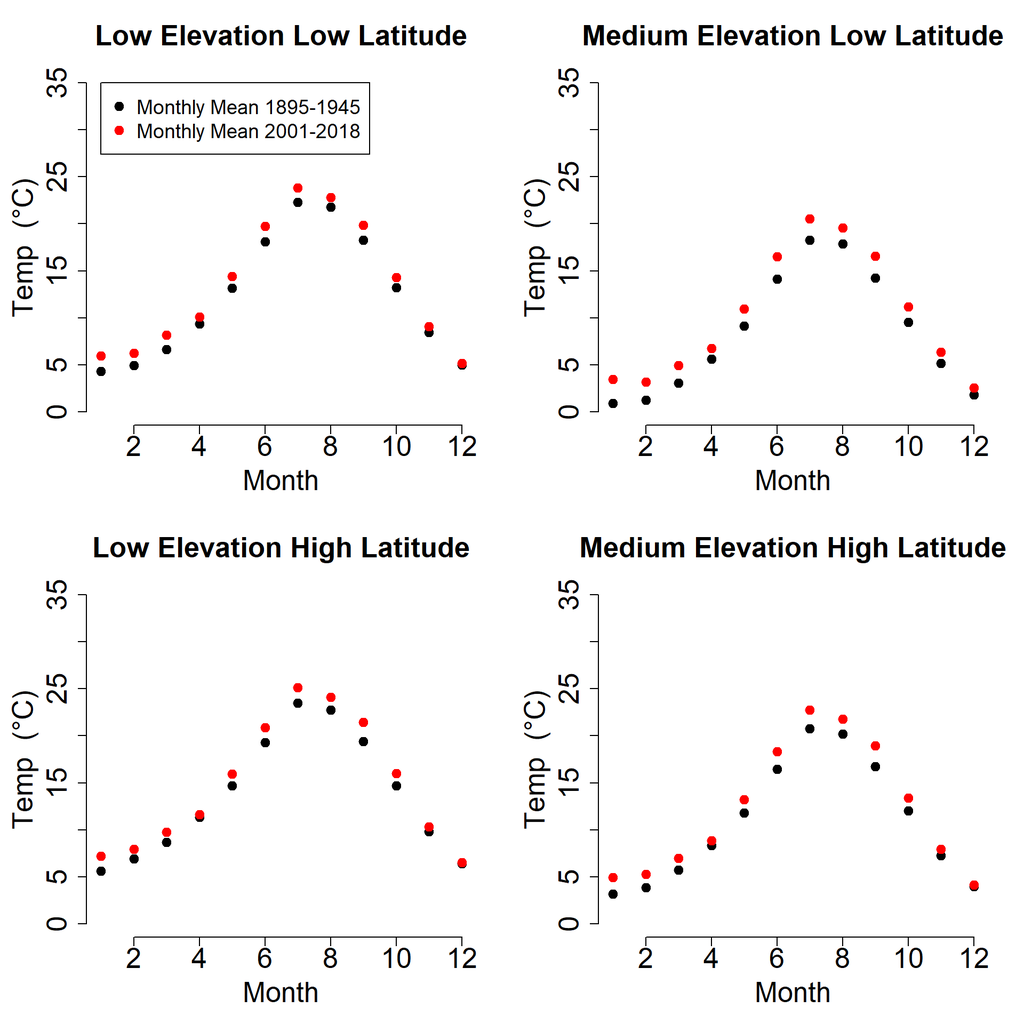

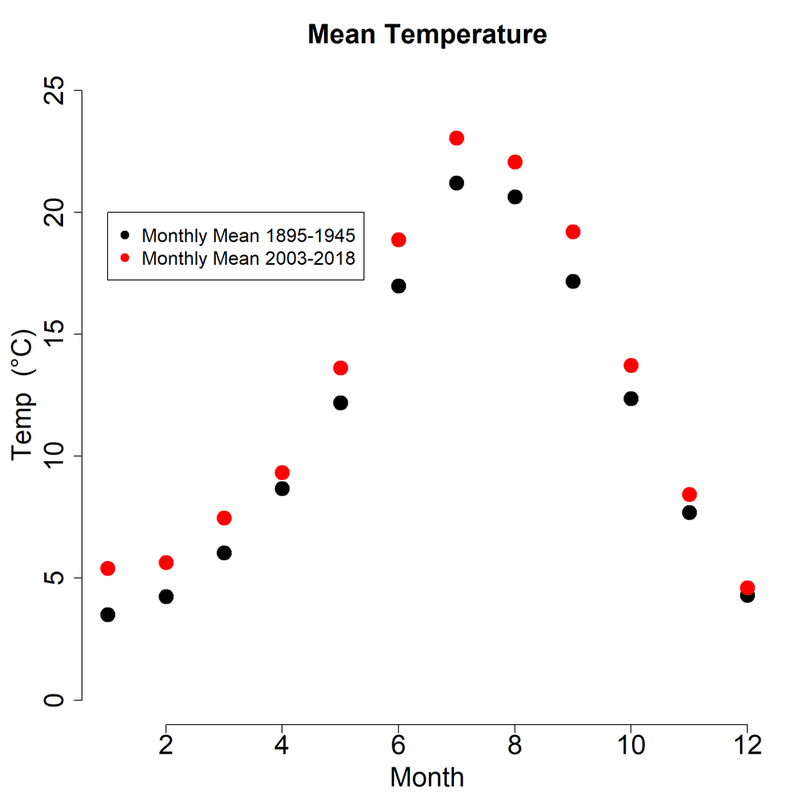

Lastly we formulate these two data sets into two .csvs for running within the model.